# Adapter and Quality Filtering

Deborah Velez-Irizarry

Updated Jan 31, 2020

### Description

In this tutorial, we will cover Illumina adapter trimming and quality filtering. Before we start this step we will need to merge fastq files per animal.

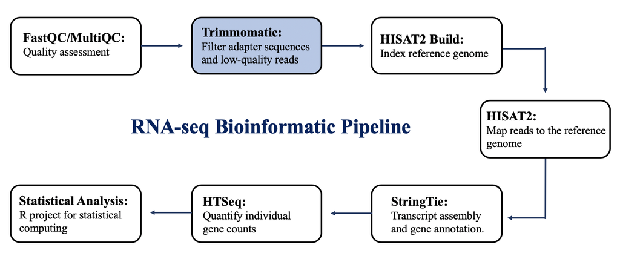

### Connect to HPC system

If you are using Ubuntu, open up the terminal with `Ctrl`+`Alt`+`T`. From the command line, log in to HPC using ssh.

**SSH**

```bash
ssh -YX username@gateway.hpcc.msu.edu
```

If you are using the remote desktop environment login to your terminal through the Web-based remote desktop: [Web site access to HPCC](https://wiki.hpcc.msu.edu/display/ITH/Web+Site+Access+to+HPCC)

### Check FASTQ Files

Before we start, lets double check that we have paired-end FASTQ files per sample ID. The following script is run interactively to make sure all files are present in the RAW directory.

First, save the script to the working directory `RNAseq_pipeline`.

```bash
nano $HOME/RNAseq_Pipeline/check_raw_files.sh
```

> Copy the following script and paste in the terminal editor window.

```bash
#======================================================================
#   Script: check_raw_files.sh
#   Directory Code: $HOME/RNAseq_Pipeline
#   Date: January 31, 2020
#   Description: This script checks that each sample ID
#   has paired-end fastq file. This script is run
#   interactively and if you get an error for a specific
#   file, that file is missing from the directory and needs
#   to be uploaded.
#   Run: bash check_raw_files.sh
#----------------------------------------------------------------------
#   Input files in directory:
#       $SCRATCH/RAW/*fastq
#======================================================================

# Directory of fastq files
Raw=$SCRATCH/RAW

# Animal IDs
cd $Raw
anim=(`ls *.fastq | cut -f1 -d_ | uniq`)

# Check that you have the paired fastq files per sample
# If you get an error stating that the file is not found
# in that directory, that file is missing

for ((i=0; i<${#anim[@]} ; i++ )) do

ls $Raw/${anim[$i]}_*1*.fastq > $Raw/check
ls $Raw/${anim[$i]}_*2*.fastq >> $Raw/check

done

rm $Raw/check
```

> Save the script by pressing `Ctrl o` and `enter`. To exit press `Ctrl x`.

**NOTE:** If the extension of your fastq files is not `fastq` you will need to change the above script to match your files extension. If this applies to your data, run the following code snippet in the terminal to change `fastq` to `fq` extension.

```bash
sed -i 's/fastq/fq/g' check_raw_files.sh
```

Run the check script with `bash`:

```bash
bash $HOME/RNAseq_Pipeline/check_raw_files.sh
```

The check files script should produce no output, indicating that both fwd and rev fastq files are present in your RAW folder. Now, if got an error stating a file could not be found, make a note of the file ID and upload that file to your RAW directory before proceeding to the next step.

### Merge Fasta files

In our example, we ran a second lane to increase the number of reads per animal, so we will need to merge these extra reads for the first and second strand separately. If you do not have multiple sequence runs per animal, you still need to run the merge script to ensure the compatibility of file names and directories in the subsequent steps of the pipeline.

**NOTE:** The following script takes as input ID_*1*.fastq and ID_*2*.fastq when retrieving fastq files per ID. If the naming scheme of your fastq data contains extra information, such as `ID_S13_L002_R2_001.fastq`, do not run the script, you risk merging more files than intended. You will need to rename your data to avoid complications. If this applies to you and you need assistance in renaming your files, please email me your file names so that I can assist.

Save the master script to merge files in your working directory `RNAseq_pipeline`.

```bash
nano $HOME/RNAseq_Pipeline/Merge_RNASeq_reads_per_animal.sh
```

> Copy the following script and paste in the terminal editor window.

```bash
#======================================================================
#   Script: Merge_RNASeq_reads_per_animal.sh
#   Directory Code: $HOME/RNAseq_Pipeline/Merged
#   Date: January 31, 2020
#   Description: Merge RNA-Seq reads for each animal into
#          a single fastq file.
#   Run: bash Merge_RNASeq_reads_per_animal.sh
#----------------------------------------------------------------------
#   Input files in directory:
#       $SCRATCH/RAW
#
#   Output files to scratch directory:
#       $SCRATCH/Merged
#======================================================================

# Directory of fastq files
Raw=$SCRATCH/RAW

# Directory for merged fastq files
mkdir $HOME/RNAseq_Pipeline/Merged
mkdir $SCRATCH/Merged
Merg=$SCRATCH/Merged

# Batch script statistics directory
mkdir $HOME/RNAseq_Pipeline/Merged/qstat
qstat=$HOME/RNAseq_Pipeline/Merged/qstat

# Move script to work directory
mv $HOME/RNAseq_Pipeline/Merge_RNASeq_reads_per_animal.sh $HOME/RNAseq_Pipeline/Merged

# Animal IDs
cd $Raw
anim=(`ls *.fastq | cut -f1 -d_ | uniq`)

# Merge reads per animal
for ((i=0; i<${#anim[@]} ; i++ )) do
echo '#!/bin/bash
#SBATCH --nodes=1
#SBATCH --cpus-per-task=1
#SBATCH --time=01:00:00
#SBATCH --mem=50G
#SBATCH -J '${anim[$i]}'
#SBATCH -o '${anim[$i]}.o%j'

# Change to merged directory
cd '$Merg'

# Files to merge
echo "List of files to merge for '${anim[$i]}'"
ls -ltrh '$Raw'/'${anim[$i]}'_*.fastq

# Merge R1 fastq files for '${anim[$i]}'
R1=(`ls '$Raw'/'${anim[$i]}'_*1*.fastq`)
for ((j=0; j<${#R1[@]} ; j++ )) do
cat ${R1[$j]} >> '${anim[$i]}'_R1_merged.fastq
done

# Merge R2 fastq files for '${anim[$i]}'
R2=(`ls '$Raw'/'${anim[$i]}'_*2*.fastq`)
for ((j=0; j<${#R2[@]} ; j++ )) do
cat ${R2[$j]} >> '${anim[$i]}'_R2_merged.fastq
done

# qstat
scontrol show job $SLURM_JOB_ID' > $qstat/${anim[$i]}.qsub

# Submit job to hpcc
cd $qstat
sbatch ${anim[$i]}.qsub

done
```

> Save the script by pressing `Ctrl o` and `enter`. To exit press `Ctrl x`.

**NOTE:** Again, if the extension of your fastq files is not `fastq`, you will need to change the above script to the extension of your files. If this applies to your data, run the following code snippet in the terminal to change `fastq` to `fq`. This is the last time you will need to make this correction. The above script will rename your files to the fastq extension.

```bash
sed -i 's/fastq/fq/g' Merge_RNASeq_reads_per_animal.sh
sed -i 's/merged.fq/merged.fastq/g' Merge_RNASeq_reads_per_animal.sh
```

Run the Merge master script with `bash`:

```bash
bash $HOME/RNAseq_Pipeline/Merge_RNASeq_reads_per_animal.sh
```

This script will create a directory in your scratch space called Merged. The merged fasta files will be saved to this directory.

### Trimmomatic

Trimmomatic is a flexable read trimming tool created for Illumina next-generation sequencing data. To learn more about Trimmomatic refer to:

> Bolger, A.M., Lohse, M., & Usadel, B. (2014). [Trimmomatic: A flexible trimmer for Illumina Sequence Data.](https://www.ncbi.nlm.nih.gov/pubmed/24695404) Bioinformatics, btu170. [Trimmomatic Website](http://www.usadellab.org/cms/index.php?page=trimmomatic)

The parameters used to performe this step are as follows:

**ILLUMINACLIP:** Cuts the Illumina-sequence specific adapters. We will trim the TruSeq3-PE adapter sequences shown below.

> PrefixPE/1 TACACTCTTTCCCTACACGACGCTCTTCCGATCT PrefixPE/2 GTGACTGGAGTTCAGACGTGTGCTCTTCCGATCT PE1 TACACTCTTTCCCTACACGACGCTCTTCCGATCT PE1_rc AGATCGGAAGAGCGTCGTGTAGGGAAAGAGTGTA PE2 GTGACTGGAGTTCAGACGTGTGCTCTTCCGATCT PE2_rc AGATCGGAAGAGCACACGTCTGAACTCCAGTCAC

**HEADCROP** Cut a specific number of bases from the start of the read. We will trim the first 6 bases.

**LEADING** Cut the leading bases only if below a quality of 3

**TRAILING** Cut the trailing bases only if below a quality of 3

**SLIDINGWINDOW** Sliding window to scan read, we will use a 4-base window and trim if the average quality is below 15.

**MINLEN** Drop reads with a minumin length of 75 bases.

First, save the master script to the working directory you created for the RNAseq pipeline tutorial.

```bash
nano $HOME/RNAseq_Pipeline/adapter_trimming.sh
```

> Copy the following script and paste in the terminal editor window.

```bash
#======================================================================
#   File: adapter_trimming.sh
#   Directory code: $HOME/RNAseq_Pipeline/Trimmomatic
#   Date: January 31, 2020
#   Description: Trim adapter sequences using Trimmomatic software
#   Run: bash adapter_trimming.sh
#----------------------------------------------------------------------
#   Input files in directory:
#       $SCRATCH/Merged/*fastq
#
#   Output files to directories in scratch:
#       $SCRATCH/Trimmomatic/PE
#       $SCRATCH/Trimmomatic/SE
#======================================================================

### Raw RNA-seq Directory
raw=$SCRATCH/Merged

### Animal IDs
cd $raw
anim=(`ls *.fastq | cut -f1 -d_ | uniq`)

### Output directories
# Trimmomatic directory
mkdir $HOME/RNAseq_Pipeline/Trimmomatic
mkdir $SCRATCH/Trimmomatic
trim=$SCRATCH/Trimmomatic

# Bash qstatistics directory
mkdir $HOME/RNAseq_Pipeline/Trimmomatic/qstat
qstat=$HOME/RNAseq_Pipeline/Trimmomatic/qstat

# Paired end reads directory
mkdir $SCRATCH/Trimmomatic/PE
pe=$SCRATCH/Trimmomatic/PE

# Single end reads directory
mkdir $SCRATCH/Trimmomatic/SE
se=$SCRATCH/Trimmomatic/SE

## Move bash script to work directory
mv $HOME/RNAseq_Pipeline/adapter_trimming.sh $HOME/RNAseq_Pipeline/Trimmomatic


### Generate bash scripts to run trimmomatic per animal
for((i=0;$i<${#anim[@]};i++))
do

echo '#!/bin/bash
#SBATCH --nodes=1
#SBATCH --cpus-per-task=1
#SBATCH --time=03:00:00
#SBATCH --mem=10G
#SBATCH -J '${anim[$i]}'
#SBATCH -o '${anim[$i]}_%j'

module load Trimmomatic

# Work directory
cd '$trim'

# Filter adaptor sequences from fastq
java -jar $EBROOTTRIMMOMATIC/trimmomatic-0.38.jar PE '$raw'/'${anim[$i]}'_R1_merged.fastq '$raw'/'${anim[$i]}'_R2_merged.fastq '${anim[$i]}'_R1_merged_PE.fastq '${anim[$i]}'_R1_merged_SE.fastq '${anim[$i]}'_R2_merged_PE.fastq '${anim[$i]}'_R2_merged_SE.fastq ILLUMINACLIP:$EBROOTTRIMMOMATIC/adapters/TruSeq3-PE-2.fa:2:30:10 HEADCROP:6 LEADING:3 TRAILING:3 SLIDINGWINDOW:4:15 MINLEN:75

# Move paired end files to PE and singles to SE
mv '${anim[$i]}'_R1_merged_PE.fastq '${anim[$i]}'_R2_merged_PE.fastq '$pe'
mv '${anim[$i]}'_R1_merged_SE.fastq '${anim[$i]}'_R2_merged_SE.fastq '$se'

# qstat
scontrol show job $SLURM_JOB_ID' > $qstat/${anim[$i]}.qsub

# Submit job to hpcc
cd $qstat
sbatch ${anim[$i]}.qsub

done
```

> Save the script by pressing `Ctrl o` and `enter`. To exit press `Ctrl x`.

Submit the master script for Trimmomatic to the SLURM scheduler.

```bash
bash $HOME/RNAseq_Pipeline/adapter_trimming.sh
```

This step should take about an hour to run. Wait until all jobs have finished before continuing to the step; check the job status with `qs`. When all jobs have finished run the checkjobs within the `qstat` directory to make sure the jobs ran with no errors.

```bash
cd $HOME/RNAseq_Pipeline/Trimmomatic/qstat
checkJobs
```

### Generate summary for quality trimming

To keep complete documentation of retained and dropped reads, we will create a summary file for each step in the RNA-seq bioinformatics pipeline. We will extract this information from the job output files (one per animal or animal-timepoint depending on the experimental design). Let us look at how Trimmomatic provides this information:

```bash
cd $HOME/RNAseq_Pipeline/Trimmomatic/qstat
cat `ls | grep -v qsub | head -1`
```

Observe the number provided for `Input Read Pair`, `Both Surviving`, `Forward Only Surviving`, `Reverse Only Surviving`, and `Dropped`. Notice that this quality step generates both paired and single reads, this happens when the trimming results in a complete loss of one of the read pairs. We will extract this information for each of the jobs submitted and save it to a tab-delimited matrix that we will use at the end of the pipeline to asses retained and loss reads.

```bash
nano $HOME/RNAseq_Pipeline/merge_rst_trim_adapters.sh
```

> Copy the following script and paste in the terminal editor window.

```bash
#===================================================================
#   File: merge_rst_trim_adapters.sh
#   Directory: $HOME/RNAseq_Pipeline/Trimmomatic
#   Date: January 31, 2020
#   Description: Check that all files were properly trimmed and merge
#                all the results.
#   Run: bash merge_rst_trim_adapters.sh
#-------------------------------------------------------------------
#   Input files in directory:
#       $HOME/RNAseq_Pipeline/Trimmomatic/qstat
#
#   Output file to directory:
#       $HOME/RNAseq_Pipeline/Trimmomatic
#
#   Output file:
#       rst_trim_adapt.txt
#       trimmomatic_rst.txt
#====================================================================

### Raw RNA-seq Directory
raw=$SCRATCH/Merged

### Animal IDs
cd $raw
anim=(`ls *.fastq | cut -f1 -d_ | uniq`)

### Output directory
trim=/$SCRATCH/Trimmomatic

### Input directory
rst=$HOME/RNAseq_Pipeline/Trimmomatic

### Qstat directory
qstat=$HOME/RNAseq_Pipeline/Trimmomatic/qstat

## Move bash script to Trimmomatic directory
mv $HOME/RNAseq_Pipeline/merge_rst_trim_adapters.sh $HOME/RNAseq_Pipeline/Trimmomatic

# Check if you have an output for each file
pe=$trim/PE
se=$trim/SE

# Paired
# If all jobs generated output you should not get any output.
for ((i=0; i<${#anim[@]} ; i++ )) do
ls $pe/${anim[$i]}_R1_merged_PE.fastq > $pe/temp
ls $pe/${anim[$i]}_R2_merged_PE.fastq > $pe/temp
done; rm $pe/temp

# Single
# If all jobs generated output you should not get any output.
for ((i=0; i<${#anim[@]} ; i++ )) do
ls $se/${anim[$i]}_R1_merged_SE* > $se/temp
ls $se/${anim[$i]}_R2_merged_SE* > $se/temp
done; rm $se/temp

# Check if all files completed successfully
# If all jobs generated output you should not get any output.
cd $qstat
for ((i=0; i<${#anim[@]} ; i++ )) do
echo `echo -n ''${anim[$i]}' ' ;  grep 'TrimmomaticPE: C' ${anim[$i]}_*` >> ../completed.txt
done

# Merge Results and save to text file
grep 'Input Read Pairs' * > $rst/rst_trim_adapt.txt

# Creat text file with trimmomatic counts for each animal
D=$rst/rst_trim_adapt.txt
cat $D | cut -f1 -d_ > id
cat $D | cut -f4 -d' ' > input.read.pairs
cat $D | cut -f7 -d' ' > both.surviving
cat $D | cut -f12 -d' ' > fwd.only.surviving
cat $D | cut -f17 -d' ' > rev.only.surviving
cat $D | cut -f20 -d' ' > dropped

echo id input.read.pairs both.surviving fwd.only.surviving rev.only.surviving dropped > trimmomatic_rst.txt
cat trimmomatic_rst.txt | tr ' ' '\t' > tmp; mv tmp $rst/trimmomatic_rst.txt
paste id input.read.pairs both.surviving fwd.only.surviving rev.only.surviving dropped >> $rst/trimmomatic_rst.txt
rm id input.read.pairs both.surviving fwd.only.surviving rev.only.surviving dropped
```

> Save the script by pressing `Ctrl o` and `enter`. To exit press `Ctrl x`.

Run the script using bash.

```bash
bash $HOME/RNAseq_Pipeline/merge_rst_trim_adapters.sh
```

This bash script will be run interactively, meaning that it will not be submitted to the scheduler. An error generated from this script will point you to a job that did not produce output. If you get an error, rerun the qsub script for that file. Refer to the qstat job output file for further instructions. If the job did not finish in the time allocated or used up more memory than requested, you would need to edit the qsub file and increase the required resources before resubmitting the job to SLURM.

Let us review the summary files generated.

```bash
cd $HOME/RNAseq_Pipeline/Trimmomatic
cat trimmomatic_rst.txt
```

We would expect a high percentage of retained paired reads and about less than 2.5% dropped reads in this step. Let us review the percent of retained paired reads and dropped reads.

```bash
cd $HOME/RNAseq_Pipeline/Trimmomatic
cat rst_trim_adapt.txt | cut -f1,8,21 -d' '
```